# StudentAnaliza

# Ulazimo u početak inferencijalne statistike sa uzorkovanjem

Pošto dataset ima jako puno opažanja, daje nam se dobra prilika uzimanja uzorka primjerene veličine (prateći standardna pravila za veličinu uzorka, 385 je dovoljno ako imamo populaciju od ili veše od 1000000). Uzimamo uzak veličine od 364 opažanja i svih 20 varijabli.

```r
set.seed(123)
uzorak_stud_364 <- stud_perf_fact[sample(1:nrow(stud_perf_fact), 364),]
dim(uzorak_stud_364)
```

```
## [1] 364  20
```

```r
head(uzorak_stud_364)
```

```
##      hours_studied attendance parental_involvement access_to_resources
## 2463            23         85               Medium                High
## 2511            23         81               Medium                 Low
## 2227            29         97                 High              Medium
## 526              9         79               Medium                 Low
## 4291            23         89                  Low              Medium
## 2986            14         78                 High              Medium
##      extracurricular_activities sleep_hours previous_scores motivation_level
## 2463                         No           7              66              Low
## 2511                        Yes           7              74           Medium
## 2227                         No           7              86           Medium
## 526                          No           7              90             High
## 4291                         No           9              88             High
## 2986                        Yes           6              69             High
##      internet_access tutoring_sessions family_income teacher_quality
```

[output cut: 20 more lines]

Pregled deskriptivne analize uzorka

```r
describe(uzorak_stud_364)[, c(3:5, 8, 9, 11, 12)]
```

```
##                              mean    sd median min max  skew kurtosis
## hours_studied               19.75  6.03     20   3  38 -0.11     0.02
## attendance                  80.42 11.53     80  60 100 -0.03    -1.21
## parental_involvement*        2.09  0.71      2   1   3 -0.12    -1.01
## access_to_resources*         2.14  0.72      2   1   3 -0.22    -1.09
## extracurricular_activities*  1.60  0.49      2   1   2 -0.40    -1.84
## sleep_hours                  7.04  1.49      7   4  10 -0.01    -0.54
## previous_scores             75.93 14.39     76  50 100 -0.10    -1.21
## motivation_level*            1.85  0.69      2   1   3  0.21    -0.91
## internet_access*             1.92  0.28      2   1   2 -3.02     7.17
## tutoring_sessions            1.51  1.17      1   0   6  0.78     0.62
## family_income*               1.85  0.75      2   1   3  0.26    -1.20
## teacher_quality*             2.20  0.60      2   1   3 -0.11    -0.46
## school_type*                 1.31  0.46      1   1   2  0.80    -1.36
## peer_influence*              1.70  0.46      2   1   2 -0.86    -1.26
## physical_activity            2.88  1.04      3   0   6 -0.13     0.26
## learning_disabilities*       1.09  0.29      1   1   2  2.78     5.76
## parental_education_level*    1.71  0.77      2   1   3  0.53    -1.13
## distance_from_home*          1.45  0.64      1   1   3  1.11     0.08
## gender*                      1.42  0.49      1   1   2  0.32    -1.90
## exam_score                  67.28  3.66     67  58  97  1.35    10.73
```

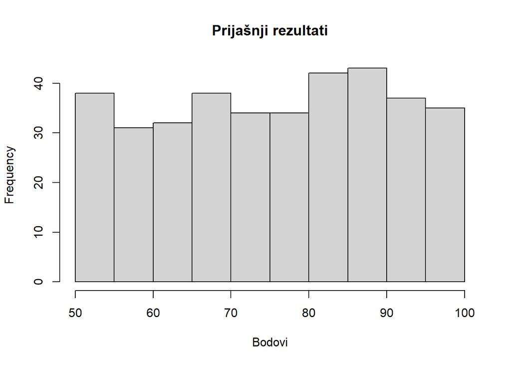

```r
hist(uzorak_stud_364$previous_scores, main="Prijašnji rezultati", xlab = "Bodovi")
```

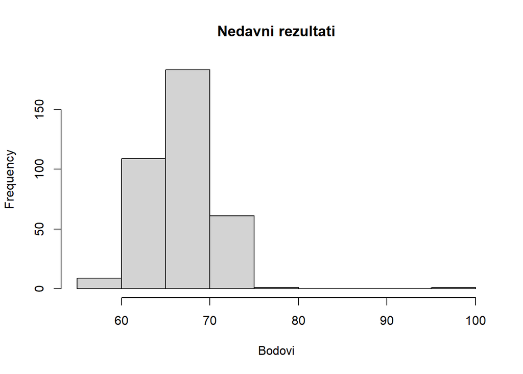

```r
hist(uzorak_stud_364$exam_score, main="Nedavni rezultati", xlab= "Bodovi")
```

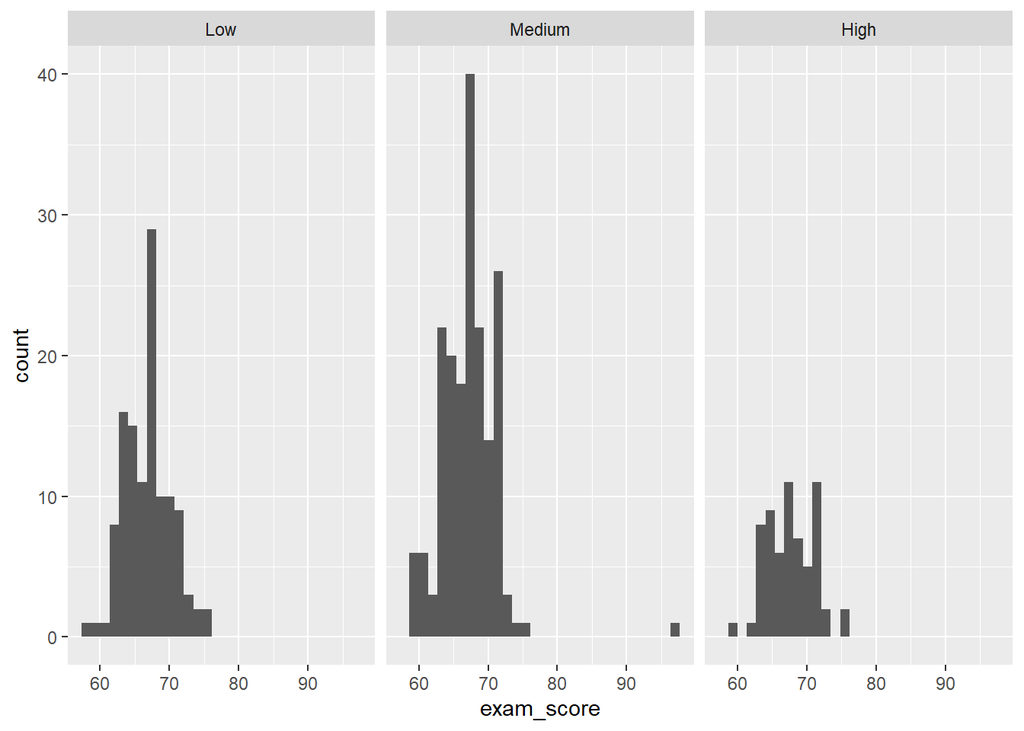

```r
ggplot(uzorak_stud_364, aes(x = exam_score)) +
  geom_histogram() +
  facet_wrap(~ motivation_level)
```

Utjecaj veličine uzorka

```r
set.seed(123)
uzorak_stud_600 <- stud_perf_fact[sample(1:nrow(stud_perf_fact), 600),]
dim(uzorak_stud_600)
```

```
## [1] 600  20
```

Mogu se primijetiti sitne promjene u vrijednostima deskriptivne statistike, koje ne utječu puno na već opisano objašnjenje prijašnjeg uzorka.

```r
describe(uzorak_stud_600)[, c(3:5, 8, 9, 11, 12)]
```

```
##                              mean    sd median min max  skew kurtosis
## hours_studied               19.65  5.73     20   3  38 -0.05     0.01
## attendance                  79.96 11.45     79  60 100  0.05    -1.20
## parental_involvement*        2.11  0.69      2   1   3 -0.14    -0.91
## access_to_resources*         2.13  0.71      2   1   3 -0.19    -1.01
## extracurricular_activities*  1.58  0.49      2   1   2 -0.31    -1.91
## sleep_hours                  7.00  1.47      7   4  10  0.01    -0.53
## previous_scores             75.87 14.28     76  50 100 -0.11    -1.14
## motivation_level*            1.85  0.70      2   1   3  0.21    -0.95
## internet_access*             1.91  0.29      2   1   2 -2.86     6.18
## tutoring_sessions            1.51  1.22      1   0   6  0.86     0.78
## family_income*               1.84  0.76      2   1   3  0.27    -1.22
## teacher_quality*             2.19  0.60      2   1   3 -0.11    -0.44
## school_type*                 1.31  0.46      1   1   2  0.81    -1.34
## peer_influence*              1.69  0.46      2   1   2 -0.80    -1.37
## physical_activity            2.90  1.06      3   0   6 -0.08     0.18
## learning_disabilities*       1.10  0.30      1   1   2  2.60     4.77
## parental_education_level*    1.74  0.77      2   1   3  0.49    -1.17
## distance_from_home*          1.51  0.67      1   1   3  0.94    -0.31
## gender*                      1.44  0.50      1   1   2  0.26    -1.93
## exam_score                  67.24  4.15     67  56 100  2.20    15.59
```

Provjera normalnosti distribucije nekolicine varijabli prvog uzorka (uzorak_stud_364) koristeći Shapiro-Wilk test. Primijećuje se da varijabla “hours_studied” zadovoljava test normalnosti za razliku od varijabli “attendance”, “sleep_hours” i “exam_score”

```r
shapiro_test(uzorak_stud_364$hours_studied)
```

```
## # A tibble: 1 × 3
##   variable                      statistic p.value
##   <chr>                             <dbl>   <dbl>
## 1 uzorak_stud_364$hours_studied     0.992  0.0618
```

```r
shapiro_test(uzorak_stud_364$attendance)
```

```
## # A tibble: 1 × 3
##   variable                   statistic       p.value
##   <chr>                          <dbl>         <dbl>
## 1 uzorak_stud_364$attendance     0.953 0.00000000216
```

```r
shapiro_test(uzorak_stud_364$sleep_hours)
```

```
## # A tibble: 1 × 3
##   variable                    statistic       p.value
##   <chr>                           <dbl>         <dbl>
## 1 uzorak_stud_364$sleep_hours     0.952 0.00000000185
```

```r
shapiro_test(uzorak_stud_364$exam_score)
```

```
## # A tibble: 1 × 3
##   variable                   statistic  p.value
##   <chr>                          <dbl>    <dbl>
## 1 uzorak_stud_364$exam_score     0.918 3.67e-13
```

# Testiranje hipoteza

```r
#cor(uzorak_stud_364$exam_score, uzorak_stud_364$distance_from_home, method = "pearson")
#cor(uzorak_stud_364$exam_score,uzorak_stud_364$distance_from_home, method = "spearman")
```

Ovisno o normalnosti distribucija, odabirati će se prikladni parametrijski i neparametrijski testovi.

2. hipoteza: NEOVISNOST H0 - varijabla “attendance” i “parental_involvement” su neovisne. H1 - varijabla “attendance” i “parental_involvement” su zavisne.

Tablica kontingencije “attendance” & “parental_involvement”

```r
table(uzorak_stud_364$attendance, uzorak_stud_364$parental_involvement)
```

```
##
##       Low Medium High
##   60    0      2    0
##   61    4      3    2
##   62    1      4    6
##   63    2      6    2
##   64    1      4    2
##   65    5      1    1
##   66    2      3    2
##   67    1      5    4
##   68    1      5    6
##   69    1      4    3
##   70    1      4    3
##   71    2      2    3
##   72    3      1    2
```

[output cut: 28 more lines]

```r
chisq.test(uzorak_stud_364$attendance, uzorak_stud_364$parental_involvement)
```

```
##
##  Pearson's Chi-squared test
##
## data:  uzorak_stud_364$attendance and uzorak_stud_364$parental_involvement
## X-squared = 91.095, df = 80, p-value = 0.1863
```

Uzeći u obzir mogućnost sitne pogreške aproksimacije rezultata testa i primijećujući X^2 vrijednosti 91.095 i p vrijednosti 0.1863 (veće od 0.001) odbija se alternativna hipoteza. Na razini značajnosti 5% prihvaća se pretpostavka da su varijable broj prisustava i razine roditeljskog utjecaja međusobno neovisne. Zaključuje se da su ove varijable međusobno nezavisne.

3. hipoteza: ANOVA/KRUSKAL-WALLIS H0 - ne postoji razlika u razini REZULTATA S OBZIROM NA RAZINU školovanja roditelja

H1 - postoji razlika u razini REZULTATA S OBZIROM NA RAZINU školovanja roditelja

```r
kruskal_test(uzorak_stud_364, uzorak_stud_364$exam_score ~ uzorak_stud_364$parental_education_level)
```

```
## # A tibble: 1 × 6
##   .y.                            n statistic    df      p method
## * <chr>                      <int>     <dbl> <int>  <dbl> <chr>
## 1 uzorak_stud_364$exam_score   364      9.15     2 0.0103 Kruskal-Wallis
```

U paketu `rstatix` na raspolaganju je i funkcija `kruskal_effsize()` kojom se utvrđuje veličina efekta ($\eta^2$).

```r
kruskal_effsize(uzorak_stud_364, uzorak_stud_364$exam_score ~ uzorak_stud_364$parental_education_level)
```

```
## # A tibble: 1 × 5
##   .y.                            n effsize method  magnitude
## * <chr>                      <int>   <dbl> <chr>   <ord>
## 1 uzorak_stud_364$exam_score   364  0.0198 eta2[H] small
```

Na raspolaganju je i Dunnov post-hoc test (prikladan za korištenje kao post-hoc za Kruskal-Wallis test, ako podaci nisu upareni).

```r
DescTools::DunnTest(uzorak_stud_364$exam_score ~ uzorak_stud_364$parental_education_level)
```

```
##
##  Dunn's test of multiple comparisons using rank sums : holm
##
##                          mean.rank.diff   pval
## College-High School             13.3633 0.2795
## Postgraduate-High School        44.6579 0.0075 **
## Postgraduate-College            31.2946 0.0920 .
## ---
## Signif. codes:  0 '***' 0.001 '**' 0.01 '*' 0.05 '.' 0.1 ' ' 1
```

Boxplot prikaz

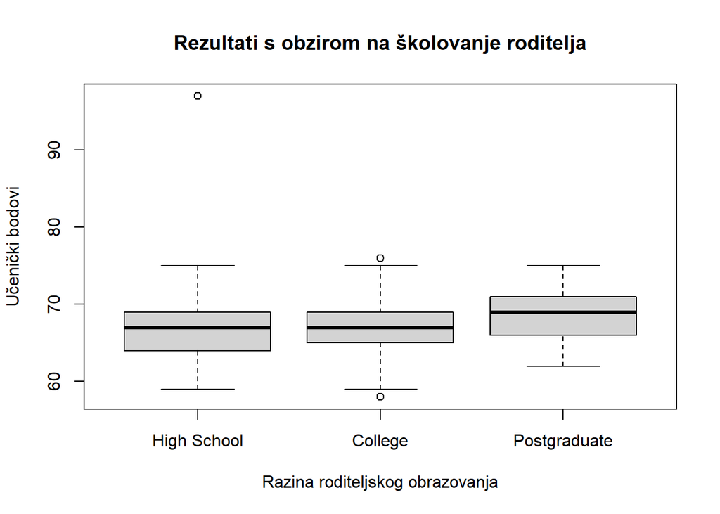

```r
boxplot(uzorak_stud_364$exam_score ~ uzorak_stud_364$parental_education_level, data = uzorak_stud_364, main="Rezultati s obzirom na školovanje roditelja", xlab="Razina roditeljskog obrazovanja", ylab="Učenički bodovi")
```

4. hipoteza: H0 - ne postoji statistički značajna razlika u utjecaju društva i poteškoće u učenju međusobno su neovisne varijable.

H1 - postoji statistički značajna razlika u utjecaju društva s obzirom na poteškoće učenja učenika/ca.

Tablica kontingencije “peer_influence” & “learning_disabilities”

```r
table(uzorak_stud_364$peer_influence, uzorak_stud_364$learning_disabilities)
```

```
##
##             No Yes
##   Negative  55   7
##   Positive 132  12
```

Odmah uvidom u tablicu se ne može primijetiti određeni društveni utjecaj na učenika ovisno dali ima poteškoća sa učenjem ili ne. Naravno slijedi konkretan službeni test da potvrdimo ili odbijemu ovo opažanje.

```r
chisq.test(uzorak_stud_364$peer_influence, uzorak_stud_364$learning_disabilities)
```

```
##
##  Pearson's Chi-squared test with Yates' continuity correction
##
## data:  uzorak_stud_364$peer_influence and uzorak_stud_364$learning_disabilities
## X-squared = 0.16833, df = 1, p-value = 0.6816
```

5. hipoteza: H0 - resursi su podjednako dostupno učenicima prema razinama obiteljskog dohotka. H1 - resursi nisu podjednako dostupno učenicima prema razinama obiteljskog dohotka.

```r
table(uzorak_stud_364$access_to_resources, uzorak_stud_364$family_income)
```

```
##
##          Low Medium High
##   Low     26     33   14
##   Medium  52     73   41
##   High    57     44   24
```

```r
chisq.test(uzorak_stud_364$access_to_resources, uzorak_stud_364$family_income)
```

```
##
##  Pearson's Chi-squared test
##
## data:  uzorak_stud_364$access_to_resources and uzorak_stud_364$family_income
## X-squared = 6.9193, df = 4, p-value = 0.1402
```

# Jednostruka linearna regresija

Jednostavna linearna regresija omogućuje nam da kvantificiramo i predvidimo odnos između dvije varijable kroz jednadžbu pravca. Pomaže nam otkriti koliko promjene u jednoj varijabli (nezavisnoj) vode do promjena u drugoj (zavisnoj), što je ključan korak u razumijevanju povezanosti pojava.

Pri izračunu parametara modela linearne regresije koristi se metoda najmanjih kvadrata, koja omogućuje utvrđivanje takvog regresijskog pravca za koji vrijedi da je suma kvadratnih odstupanja opažanja od pripadajućih vrijednosti predviđenih pravcem najmanja.

1. model - interte_access i previus_scores

```r
jlr_model1<-lm(uzorak_stud_364$previous_scores ~ uzorak_stud_364$internet_access, data= uzorak_stud_364)
jlr_model1
```

```
##
## Call:
## lm(formula = uzorak_stud_364$previous_scores ~ uzorak_stud_364$internet_access,
##     data = uzorak_stud_364)
##
## Coefficients:
##                       (Intercept)  uzorak_stud_364$internet_access.L
##                            73.869                              3.492
```

```r
summary(jlr_model1)
```

```
##
## Call:
## lm(formula = uzorak_stud_364$previous_scores ~ uzorak_stud_364$internet_access,
##     data = uzorak_stud_364)
##
## Residuals:
##      Min       1Q   Median       3Q      Max
## -26.3383 -12.3383  -0.3383  11.8963  27.6000
##
## Coefficients:
##                                   Estimate Std. Error t value Pr(>|t|)
## (Intercept)                         73.869      1.367  54.023   <2e-16 ***
## uzorak_stud_364$internet_access.L    3.492      1.934   1.806   0.0718 .
## ---
## Signif. codes:  0 '***' 0.001 '**' 0.01 '*' 0.05 '.' 0.1 ' ' 1
##
## Residual standard error: 14.35 on 362 degrees of freedom
## Multiple R-squared:  0.008927,   Adjusted R-squared:  0.00619
## F-statistic: 3.261 on 1 and 362 DF,  p-value: 0.07178
```

Tako možemo uočiti retke koji opisuju koeficijente regresije te ponovno vidjeti same vrijednosti koeficijenata β0 i β1, ali i standardne pogreške njihove procjene. Na kraju tih redaka uočavamo i p-vrijednosti. Pogledajmo donji dio tablice. Tamo prije svega nalazimo rezidualnu standardnu pogrešku RSE koja iznosi 14.35. Sjetimo se, RSE je procjena standardne devijacije od ε. Dobivenu vrijednost možemo interpretirati na način da se je stvarni rezultat prošlog ispita razlikovati od regresijskog pravca u prosjeku za 14.35 bodova.

Pogledom na dobivena svojstva modela, zaključujemo da odbacujemo model.

```r
library(lmtest)
```

Nacrtajmo na jednom grafu podatke i regresijski pravac zajedno. Ovo zapravo može biti početak regresijske analize, ali smo u prethnodnom dijelu teksta malo vremena posvetili proučavanju podataka da steknemo uvid u njihovu strukturu.

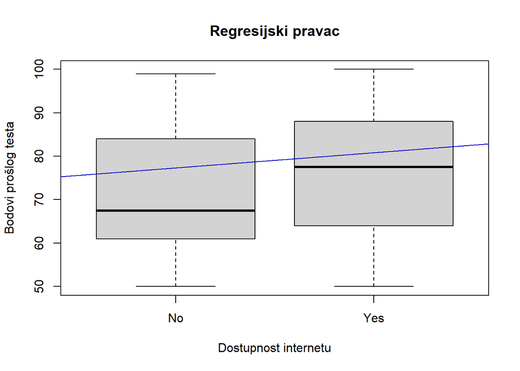

```r
plot(uzorak_stud_364$internet_access, uzorak_stud_364$previous_scores, main="Regresijski pravac", xlab="Dostupnost internetu", ylab="Bodovi prošlog testa")
abline(jlr_model1, col="blue3")
```

Kroz boxplot usporedbe mogu se vidjeti razlike interkvartilnog raspona, također i malo veči udio boljih rezultata prošle provjere znanja kod učenika/ca koji imaju pristup internetu.

2. model - exam_score i hours_studied

```r
jlr_model2<-lm(uzorak_stud_364$exam_score ~ uzorak_stud_364$hours_studied, data= uzorak_stud_364)
jlr_model2
```

```
##
## Call:
## lm(formula = uzorak_stud_364$exam_score ~ uzorak_stud_364$hours_studied,
##     data = uzorak_stud_364)
##
## Coefficients:
##                   (Intercept)  uzorak_stud_364$hours_studied
##                       60.9569                         0.3202
```

```r
summary(jlr_model2)
```

```
##
## Call:
## lm(formula = uzorak_stud_364$exam_score ~ uzorak_stud_364$hours_studied,
##     data = uzorak_stud_364)
##
## Residuals:
##     Min      1Q  Median      3Q     Max
## -7.0409 -1.9327 -0.1197  2.0476 28.0378
##
## Coefficients:
##                               Estimate Std. Error t value Pr(>|t|)
## (Intercept)                   60.95688    0.56026   108.8   <2e-16 ***
## uzorak_stud_364$hours_studied  0.32021    0.02714    11.8   <2e-16 ***
## ---
## Signif. codes:  0 '***' 0.001 '**' 0.01 '*' 0.05 '.' 0.1 ' ' 1
##
## Residual standard error: 3.118 on 362 degrees of freedom
## Multiple R-squared:  0.2778, Adjusted R-squared:  0.2758
## F-statistic: 139.2 on 1 and 362 DF,  p-value: < 2.2e-16
```

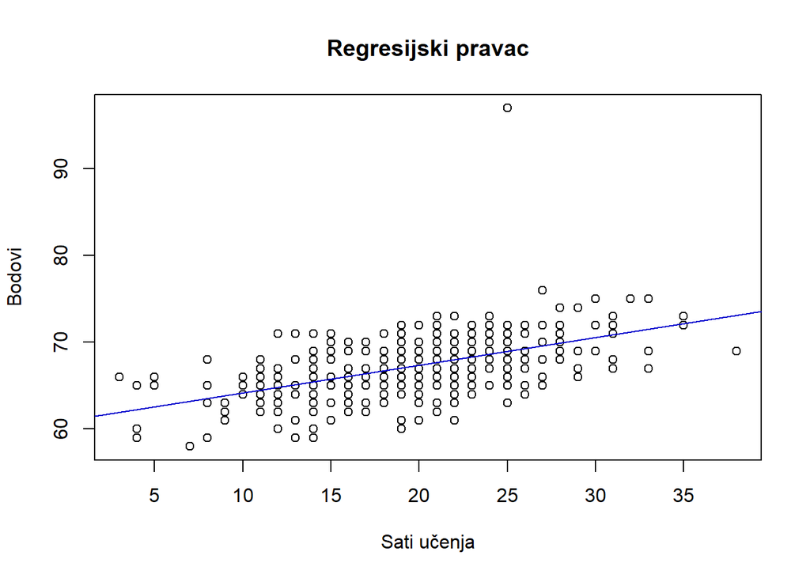

```r
plot(uzorak_stud_364$hours_studied, uzorak_stud_364$exam_score, main="Regresijski pravac", xlab="Sati učenja", ylab="Bodovi")
abline(jlr_model2, col="blue3")
```

Nažalost, pošto je veći broj varijabli kvalitativne prirode, ovdje se prestaje rad nad jednostavnoj linearnoj regresiji. Da bih se mogla nastaviti analiza potrebno je korištenje drugih vrsta regresija, poput višestruke linearne regresije i logistička regresija.

# Višestruka linearna regresija

U modelu jednostavne linearne regresije pokušavamo vrijednost slučajne varijable Yobjasniti vrijednostima jedne slučajne varijable X, korištenjem linearnog modela, naravno. Dosta je jasno da je to prilično ograničavajuće svojstvo jednostavne linearne regresije jer su u stvarnosti utjecaji na varijablu Y često višestruki. Stoga se prirodno nameće ideja da pokušamo proširiti taj model dodatnim nezavisnim varijablama. Na taj način dolazimo do višestruke linearne regresije. Za provođenje višestruke linearne regresije, za promijenu ćemo koristiti veći uzorak (uzorak od 600 opažanja).

1. model - Utjecaj provedenih sati učenja, sati spavanja i sati konzultacija na rezultate ispita

```r
vlr_model1<-lm(exam_score ~ hours_studied + sleep_hours + tutoring_sessions, data= uzorak_stud_600)
summary(vlr_model1)
```

```
##
## Call:
## lm(formula = exam_score ~ hours_studied + sleep_hours + tutoring_sessions,
##     data = uzorak_stud_600)
##
## Residuals:
##    Min     1Q Median     3Q    Max
## -8.146 -2.170 -0.203  2.006 32.197
##
## Coefficients:
##                   Estimate Std. Error t value Pr(>|t|)
## (Intercept)       61.13014    0.90631  67.450  < 2e-16 ***
## hours_studied      0.32815    0.02602  12.612  < 2e-16 ***
## sleep_hours       -0.14590    0.10101  -1.444 0.149134
## tutoring_sessions  0.44999    0.12250   3.673 0.000261 ***
## ---
## Signif. codes:  0 '***' 0.001 '**' 0.01 '*' 0.05 '.' 0.1 ' ' 1
##
## Residual standard error: 3.645 on 596 degrees of freedom
## Multiple R-squared:  0.2323, Adjusted R-squared:  0.2285
## F-statistic: 60.13 on 3 and 596 DF,  p-value: < 2.2e-16
```

2. model višestruke linearne regresije - dali učenik/ca treba više učiti ovisno o provedenim satima konzultacija u školi, prisutnosti na nastavi i fizičkim aktivnostima. Cilj je objasniti dali navedene nezavisne varijable pomažu u smanjenju vrijednosti potrebe učenja doma (zavisne varijable).

```r
vlr_model1<-lm(hours_studied ~ tutoring_sessions + attendance + physical_activity, data= uzorak_stud_600)
summary(vlr_model1)
```

```
##
## Call:
## lm(formula = hours_studied ~ tutoring_sessions + attendance +
##     physical_activity, data = uzorak_stud_600)
##
## Residuals:
##      Min       1Q   Median       3Q      Max
## -17.2948  -4.1095   0.3103   3.5074  18.9316
##
## Coefficients:
##                   Estimate Std. Error t value Pr(>|t|)
## (Intercept)       17.50440    1.79624   9.745   <2e-16 ***
## tutoring_sessions  0.22922    0.19250   1.191    0.234
## attendance         0.02692    0.02044   1.317    0.188
## physical_activity -0.12038    0.22202  -0.542    0.588
## ---
## Signif. codes:  0 '***' 0.001 '**' 0.01 '*' 0.05 '.' 0.1 ' ' 1
##
## Residual standard error: 5.73 on 596 degrees of freedom
## Multiple R-squared:  0.005812,   Adjusted R-squared:  0.0008081
## F-statistic: 1.161 on 3 and 596 DF,  p-value: 0.3237
```

# Logistička regresija i klasifikacija

U prethodnom poglavlju smo promatrali problem regresije, odnosno situacije u kojima želimo na temelju jedne ili više varijabli prediktora procijeniti vrijednost neke kvantitativne odzivne varijable Y. U praksi se vrlo često susrećemo sa situacijama u kojima odzivna varijabla Y nije numerička, nego kvalitativna. Tada govorimo o problemima klasifikacije. I naravno uzeći u obzir većinu varijabli da spadaju pod kvalitativnu vrstu varijabli.

Prije samog početka rada klasifikacije, bitno je za navesti klasifikacijska tablica i mjere kvalitete klasifikacije.

|  | stvarna ne | stvarna da |
| --- | --- | --- |
| predivđena ne | TN | FN |
| predviđena da | FP | TP |

Klasifikacijska tablica nam služi za određivanje točnosti (“Accuracy”), osjetljivosti (“Sensitivity”) i specifičnosti (“Specificity”) koristeći varijable:  
TP - broj opažanja ispravno svrstanih u klasu da (true positives)  
TN - broj opažanja ispravno svrstanih u klasu ne (true negatives)  
FP - broj opažanja pogrešno svrstanih u klasu da (false positives)  
FN - broj opažanja pogrešno svrstanih u klasu ne (false negatives)

1. model - predikcija prolazaka učenika/ce na ispitu ovisno o broju sati učenja, prisutnosti i prijašnjim rezultatima

```r
uzorak_stud_600$pass <- ifelse(uzorak_stud_600$exam_score >= 70, 1, 0)
uzorak_stud_600$pass <- as.factor(uzorak_stud_600$pass)
```

```r
log_model1 <- glm(
  pass ~ hours_studied + attendance + previous_scores, data = uzorak_stud_600,
  family = binomial
)
summary(log_model1)
```

```
##
## Call:
## glm(formula = pass ~ hours_studied + attendance + previous_scores,
##     family = binomial, data = uzorak_stud_600)
##
## Coefficients:
##                  Estimate Std. Error z value Pr(>|z|)
## (Intercept)     -29.65564    2.68895 -11.029  < 2e-16 ***
## hours_studied     0.30795    0.03628   8.488  < 2e-16 ***
## attendance        0.20829    0.01976  10.539  < 2e-16 ***
## previous_scores   0.05817    0.01086   5.358 8.42e-08 ***
## ---
## Signif. codes:  0 '***' 0.001 '**' 0.01 '*' 0.05 '.' 0.1 ' ' 1
##
## (Dispersion parameter for binomial family taken to be 1)
##
##     Null deviance: 676.99  on 599  degrees of freedom
## Residual deviance: 336.80  on 596  degrees of freedom
## AIC: 344.8
##
## Number of Fisher Scoring iterations: 7
```

```r
p1 <- predict(log_model1, type = "response")
pred_class <- ifelse(p1 > 0.5, "Yes", "No")
table(pred_class, uzorak_stud_600$pass)
```

```
##
## pred_class   0   1
##        No  418  42
##        Yes  31 109
```

Ako izračunamo ukupnu točnost klasifikacije, dobivamo
$$\frac{418+109}{600}=0.8781,$$
dakle osjetljivost, jednaka je
$$\frac{109}{109+42}\approx 0.7218,$$
S druge strane, vrlo je uspješan u prepoznavanju učenika/ca koje nisu prošle. To mjerimo specifičnošću modela i u ovom slučaju dobivamo
$$\frac{418}{418+31}\approx 0,9309.$$
Vizulani prikazi

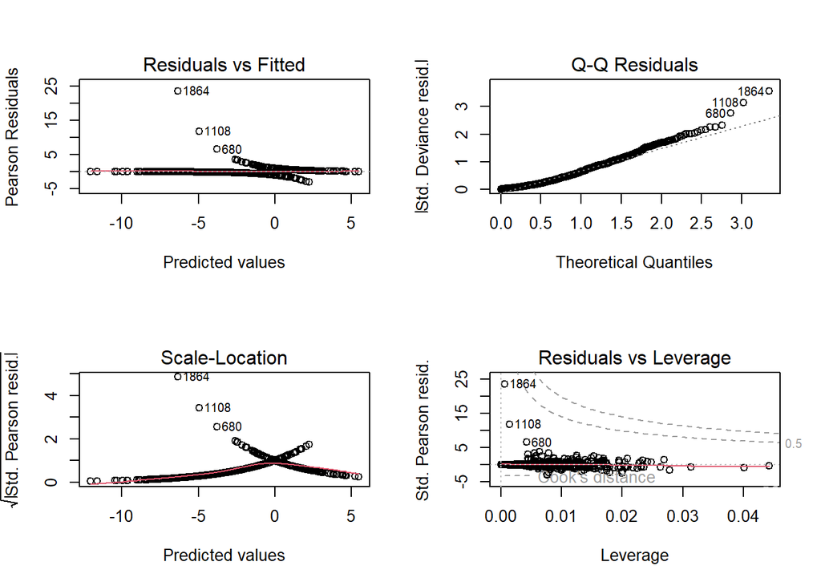

```r
par(mfrow = c(2, 2))
plot(log_model1)
```

Na prvom grafu (Residuals vs Fitted) na osi x više nemamo procijenjene vjerojatnosti, nego procijenjene vrijednosti linearnog prediktora, odnosno logita. Na osi y prikazani su Pearsonovi reziduali. Budući da je odziv binaran, prirodno je da se opažanja rasporede u dva karakteristična pojasa, pa ovdje ne očekujemo isti tip “oblaka točaka” kao kod linearne regresije. Više nas zanima postoje li opažanja s osobito velikim rezidualima ili neki dodatni sustavni obrazac koji bi upućivao na lošu prilagodbu modela. Uočimo da bi “savršen” model imao sve reziduale blizu nule.

Na drugom grafu (Normal Q-Q) prikazani su standardizirani deviance reziduali uspoređeni s teorijskim kvantilima. Ovaj graf u logističkoj regresiji ne služi za provjeru pretpostavke normalnosti reziduala, jer takva pretpostavka ovdje nije dio modela. Umjesto toga, koristan je za uočavanje opažanja s neuobičajeno velikim rezidualima, odnosno opažanja koja model posebno loše opisuje.

Treći graf (Scale-Location) također ne tumačimo kao provjeru homoskedastičnosti u smislu linearne regresije, jer varijanca ovdje prirodno nije konstantna. Taj graf može pomoći pri uočavanju eventualnih nepravilnosti u raspršenosti reziduala, ali ga ne treba promatrati kao formalni test konstantne varijance.

Četvrti graf (Residuals vs Leverage) pomaže pri prepoznavanju opažanja koja imaju velik utjecaj na procijenjeni model. Posebno su zanimljiva opažanja s velikim leverageom i velikom Cookovom udaljenošću, jer takve točke mogu osjetno utjecati na procjene koeficijenata.

2. model - nadogradnja prijašnjeg modela koji uključuje kategoričke prediktore

```r
log_model2 <- glm(
  pass ~ hours_studied +
    attendance +
    previous_scores +
    motivation_level +
    internet_access +
    family_income +
    teacher_quality +
    peer_influence +
    gender,
  data = uzorak_stud_600,
  family = binomial
)

summary(log_model2)
```

```
##
## Call:
## glm(formula = pass ~ hours_studied + attendance + previous_scores +
##     motivation_level + internet_access + family_income + teacher_quality +
##     peer_influence + gender, family = binomial, data = uzorak_stud_600)
##
## Coefficients:
##                     Estimate Std. Error z value Pr(>|z|)
## (Intercept)        -38.41782    5.05261  -7.604 2.88e-14 ***
## hours_studied        0.36835    0.06062   6.077 1.23e-09 ***
## attendance           0.26328    0.03481   7.564 3.90e-14 ***
## previous_scores      0.08299    0.01850   4.485 7.28e-06 ***
## motivation_level.L   0.91898    0.42554   2.160 0.030808 *
## motivation_level.Q   0.16266    0.35616   0.457 0.647878
## internet_access.L    0.68178    0.67192   1.015 0.310256
## family_income.L      1.64190    0.42735   3.842 0.000122 ***
## family_income.Q     -0.06397    0.35293  -0.181 0.856165
## teacher_quality.L    1.36276    0.59064   2.307 0.021039 *
## teacher_quality.Q   -0.37955    0.39649  -0.957 0.338423
## peer_influence.L     0.84037    0.33299   2.524 0.011613 *
## genderFemale         0.86338    0.44972   1.920 0.054878 .
## ---
## Signif. codes:  0 '***' 0.001 '**' 0.01 '*' 0.05 '.' 0.1 ' ' 1
##
## (Dispersion parameter for binomial family taken to be 1)
##
##     Null deviance: 380.65  on 336  degrees of freedom
## Residual deviance: 153.30  on 324  degrees of freedom
##   (263 observations deleted due to missingness)
## AIC: 179.3
##
## Number of Fisher Scoring iterations: 7
```

```r
p2 <- predict(log_model2, type = "response")
pred_class <- ifelse(p2 > 0.5, "Yes", "No")
#table(pred_class, uzorak_stud_600$pass)
```

Vizualni prikazi

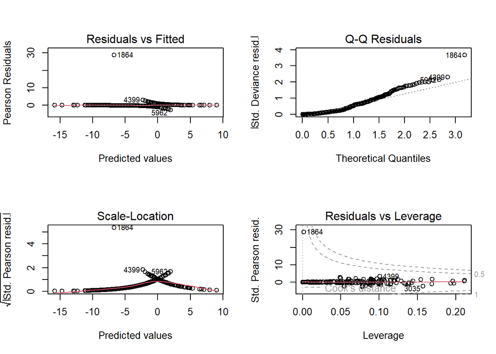

```r
par(mfrow = c(2, 2))
plot(log_model2)
```

# Zaključak

Zaključno, analiza potvrđuje da je školski uspjeh složen fenomen na koji istodobno djeluju akademski, obiteljski i socijalni čimbenici. Nijedan pojedinačni faktor ne može dovoljno dobro objasniti ostvarene rezultate učenika, dok kombinacija više varijabli daje nešto kvalitetnije, ali i dalje ograničeno objašnjenje. Za preciznije modeliranje i predviđanje uspjeha učenika preporučuje se primjena naprednijih metoda strojnog učenja ili složenijih regresijskih modela koji mogu bolje obuhvatiti nelinearne i međusobne odnose među varijablama.